# MODULE I. Descriptive Statistics & Intro to Probability. Hands-on practicum.

Julia Ponomarenko, CRG Bioinformatics core facility.

June 6, 2017

## 1. Descriptive statistics

“Descriptive statistics aim to summarize **a sample**, rather than use the data to learn about **the population** that the sample of data is thought to represent. This generally means that descriptive statistics, unlike inferential statistics, are not developed on the basis of probability theory.” (Wikipedia)

### Explore data

We will use the package “car”. For details on this package, see https://cran.r-project.org/web/packages/car/car.pdf

```r
# install.packages("car") - run this code if you do not have car" package installed
library(car)
```

Let’s explore the dataset “Davis” from the car package. It is called “Self-Reports of Height and Weight Description”. The Davis data frame has 200 rows and 5 columns. The subjects were men and women engaged in regular exercise. There are some missing data. This data frame contains the following columns:  
sex - A factor with levels: F, female; M, male.  
weight - Measured weight in kg.  
height - Measured height in cm.  
repwt - Reported weight in kg.  
repht - Reported height in cm.

```r
data <- Davis

dim(data) # first thing to do to see how many rows and columns
names(data) # columns names

class(data)  # should be "data.frame""
sapply(data[1,], class)  # to see types of variables in each column
head(data)

summary(data)  # shows quantiles for each column and how many NA's !!!!

quantile(data$repwt, na.rm = TRUE)  # shows quantiles for values in a specific column, ignoring 'NA'

unique(data$sex) # shows unique values for a specified column
unique(data$weight)
length(unique(data$weight))

table(data$sex) # table() builds a contingency table of the counts at each combination of factor levels
table(data$sex, data$weight)  # shows relationships between variables
table(data$sex, data$weight < 80) # gives the 2x2 contingency table

intervals <- cut(data$weight, quantile(data$weight)) # cut() assigns to each value a quantile - shows intervals in the order of data$weight
table(intervals, data$sex) # contigency table of sex by intervals (weight quantiles)

# contigency table of quantiles of weight versus repwt
x <- data$weight
y <- data$repwt
table(cut(x, quantile(x)), cut(y, quantile(y, na.rm = TRUE)))
```

#### Exercise with table(), cut(), and quantile()

**Who is more inclined to report lower weight, males or females?**

```r
#males only
d <- data[data$sex == "M",]
x <- d$weight
y <- d$repwt
table(cut(x, quantile(x)), cut(y, quantile(y, na.rm = TRUE)))
```

```
##
##             (56,68] (68,75] (75,83] (83,124]
##   (54,67.8]      17       1       0        0
##   (67.8,75]       4      17       2        0
##   (75,83]         0       3      14        2
##   (83,119]        0       0       2       18
```

```r
#males only
d <- data[data$sex == "F",]
x <- d$weight
y <- d$repwt
table(cut(x, quantile(x)), cut(y, quantile(y, na.rm = TRUE)))
```

```
##
##             (41,53] (53,56] (56,61] (61,77]
##   (39,52.8]      20       2       1       0
##   (52.8,56]       8      15       5       0
##   (56,62]         1       8      14       3
##   (62,166]        0       1       3      19
```

#### Looking at subset of data

```r
d <- data[data$weight < 60,] # rows with weight below 60 kg
summary(d)
summary(d$sex)
dim(d)
nrow(d)

data[data$weight < 60 & data$repwt >= 60,] # the results looks strange !!!
data[which(data$weight < 60 & data$repwt >= 60),] # use which() to exclude NA values
```

#### Missing (NA) values

```r
sum(is.na(data$repwt))  # the number of missing values for repwt
```

```
## [1] 17
```

```r
table(is.na(data$repht))  # how many complete data (FALSE) and how many missing (TRUE) for data$repht
```

```
##
## FALSE  TRUE
##   183    17
```

```r
#by default table() doesn't show missing value; e.g.
table(data$repht)
```

```
##
## 148 150 152 153 154 155 158 159 160 161 163 164 165 166 168 169 170 171
##   1   2   1   3   2   7   9   3  18   6  12   1  23   1   6   3  12   7
## 172 173 174 175 176 178 179 180 181 182 183 185 188 200
##   1   7   2  19   1   6   1   9   1   1   7   6   4   1
```

```r
table(data$repht, useNA = "ifany") #now it shows
```

```
##
##  148  150  152  153  154  155  158  159  160  161  163  164  165  166  168
##    1    2    1    3    2    7    9    3   18    6   12    1   23    1    6
##  169  170  171  172  173  174  175  176  178  179  180  181  182  183  185
##    3   12    7    1    7    2   19    1    6    1    9    1    1    7    6
##  188  200 <NA>
##    4    1   17
```

```r
#How many rows contain missing values (i.e., at least one 'NA')?
sum(!complete.cases(data))
```

```
## [1] 19
```

```r
data[!complete.cases(data), ] # here they are
```

```
##     sex weight height repwt repht
## 47    M     73    180    NA    NA
## 48    F     49    161    NA    NA
## 55    M     64    177    NA    NA
## 57    F     66    170    65    NA
## 76    F     50    171    NA    NA
## 100   F     55    155    NA   154
## 125   M     67    179    NA    NA
## 126   F     52    169    56    NA
## 127   F     47    153    NA   154
## 138   F     62    167    NA    NA
## 154   F     55    162    NA    NA
## 158   F     59    170    NA    NA
## 159   F     58    169    NA    NA
## 172   F     54    163    NA    NA
## 174   M     82    176    NA    NA
## 177   F     60    174    NA    NA
## 182   F     43    154    NA    NA
## 183   M     82    181    NA    NA
## 198   M     81    175    NA    NA
```

#### Exercise on missing values

**What is the proportion of females and males who didn’t report the weight?**

```r
f <- data[which(data$sex == "F"), ]
n <- nrow(f) #total number of females in the original data frame
y <- sum(is.na(f$repwt))/n
round(y, digits = 3)
```

```
## [1] 0.098
```

```r
m <- data[which(data$sex == "M"), ]
n <- nrow(m) #total number of males in the original data frame
y <- sum(is.na(m$repwt))/n
round(y, digits = 3)
```

```
## [1] 0.068
```

### Summary statistics

Basic R functions: mean, sd, var, min, max, median, range, IQR, and quantile. All these function require special treatment for missing values, using parameter na.rm = TRUE. While summary(data) does not.

Let’s look at the row with the maximum weight.

```r
max_weight <- max(data$weight)
data[which(data$weight == max_weight), ] # full info (row) on a person with the max_weight
```

```
##    sex weight height repwt repht
## 12   F    166     57    56   163
```

#### Outliers

Can be defined (by the Tuley’s test) as values in the sample that differ from the Q1 (25% quantile) or Q3 (75% quantile) by more than 1.5*IQR (where IQR = Q3 - Q1).  
However, there is no formal definition of outliers; they need to be treated subjectively.

```r
quantile(data$weight)
```

```
##   0%  25%  50%  75% 100%
##   39   55   63   74  166
```

```r
q <- unname(quantile(data$weight)) # unname() removes names and gives the vector of quantile values that we use below

iqr <- q[4] - q[2] # or use IQR(data$weight) instead
upper_limit <- q[4] + 1.5 * iqr # values above this limit are outliers
upper_limit
```

```
## [1] 102.5
```

```r
max_weight > upper_limit # Is the maximum weight an outlier? TRUE or FALSE?
```

```
## [1] TRUE
```

How many “formal” outliers by weight in the dataset?

```r
data[which(data$weight > upper_limit), ]
```

```
##    sex weight height repwt repht
## 12   F    166     57    56   163
## 21   M    119    180   124   178
## 97   M    103    185   101   182
```

Let’s remove these outliers and check which of the summary statistics change.

```r
d <- data[which(!data$weight > upper_limit), ] # d is our data frame without outliers; we will use it further in this practicum

# Did mean change?
mean(d$weight)
```

```
## [1] 64.83249
```

```r
mean(data$weight)
```

```
## [1] 65.8
```

```r
# Did median change?
median(data$weight)
```

```
## [1] 63
```

```r
median(d$weight)
```

```
## [1] 63
```

```r
# Did SD change?
sd(data$weight)
```

```
## [1] 15.09501
```

```r
sd(d$weight)
```

```
## [1] 12.55711
```

```r
# Did quantiles change?
quantile(data$weight)
```

```
##   0%  25%  50%  75% 100%
##   39   55   63   74  166
```

```r
quantile(d$weight)
```

```
##   0%  25%  50%  75% 100%
##   39   55   63   73  102
```

### Plots

#### Box-plot

```r
boxplot(data$weight) # we can clearly see three outliers as individual dots
data[which(data$weight > upper_limit), ] # here they are
```

[output not shown]

```
##    sex weight height repwt repht
## 12   F    166     57    56   163
## 21   M    119    180   124   178
## 97   M    103    185   101   182
```

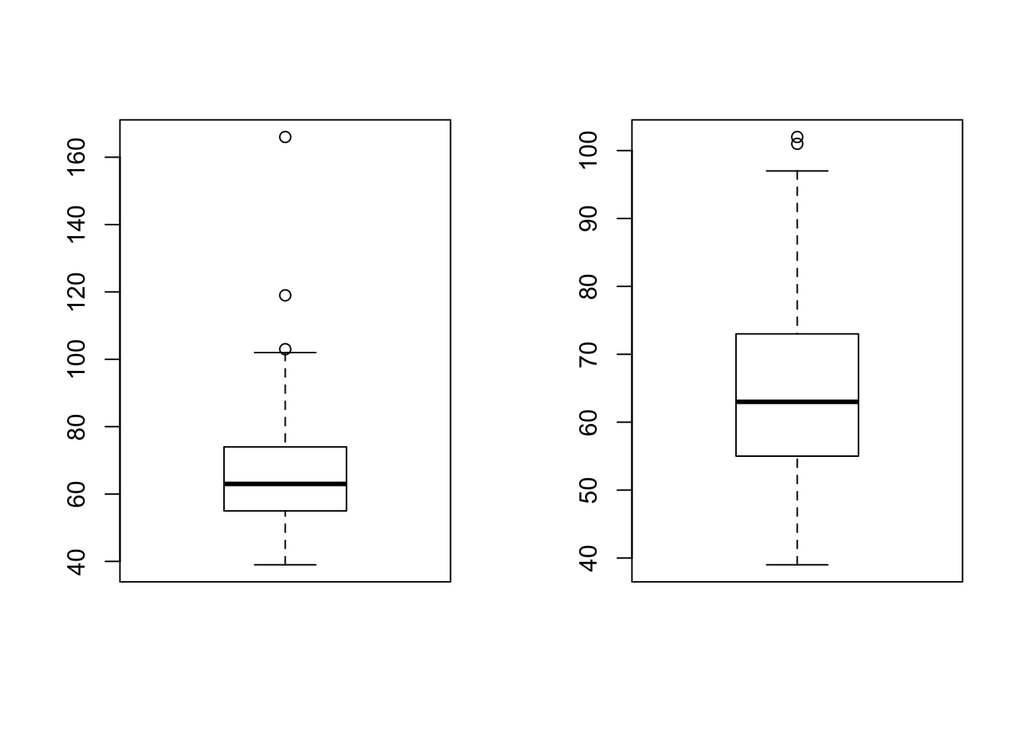

```r
#boxplots of weight values with and w/o outliers side by side
par(mfrow = c(1,2)) # par() allows to plot graphs in a table; e.g., two plots in one row
boxplot(data$weight)
boxplot(d$weight) # now we got another outliers because IQR changed
```

```r
par(mfrow = c(1,1)) # restore the default plot layout

# Let's explore these "new" outliers
quantile(d$weight)
```

```
##   0%  25%  50%  75% 100%
##   39   55   63   73  102
```

```r
q <- unname(quantile(d$weight)) # the vector of quantile values
upper_limit <- q[4] + 1.5 * IQR(d$weight) # values above this limit are
d[which(d$weight > upper_limit), ]
```

```
##    sex weight height repwt repht
## 30   M    101    183   100   180
## 54   M    102    185   107   185
```

```r
#It is up to a researcher to remove those outliers or not. Let's not remove them.
```

**How to plot box-plots side-by-side on one graph**

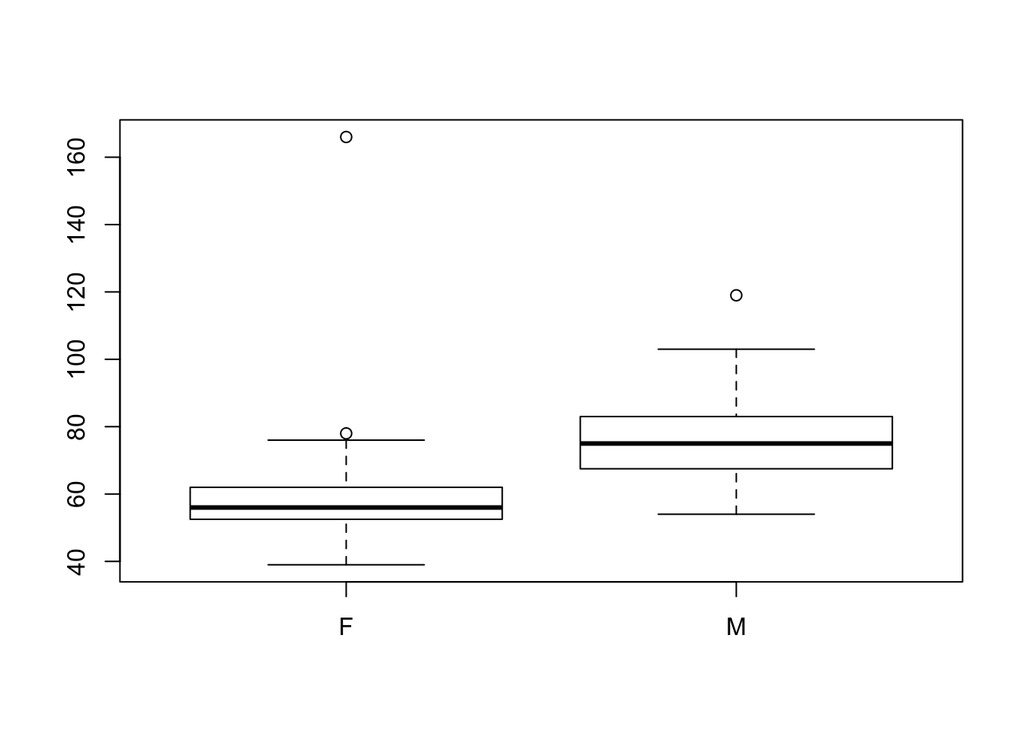

```r
boxplot(data$weight ~ data$sex)
```

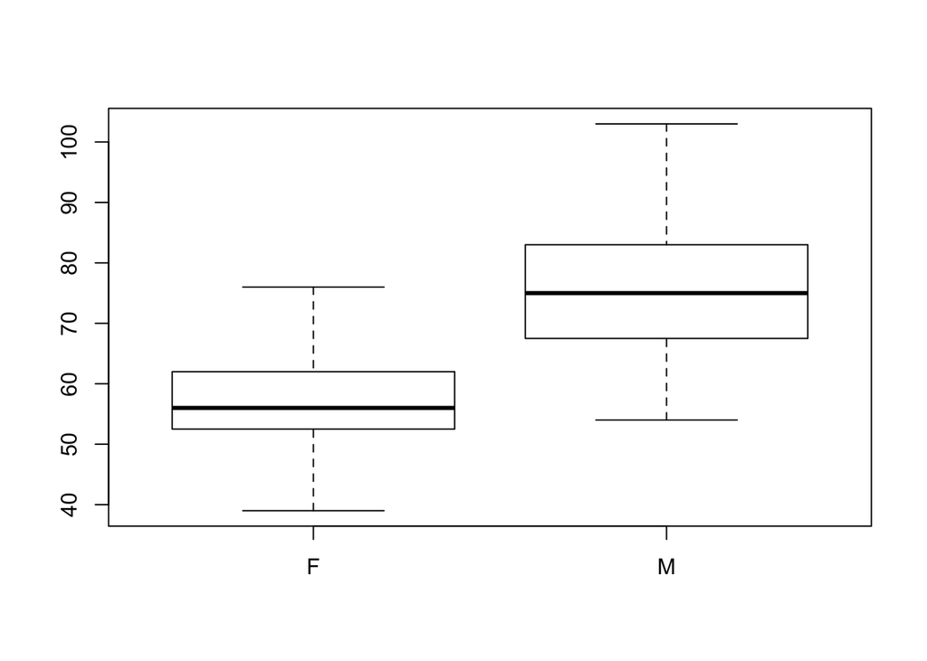

```r
boxplot(data$weight ~ data$sex, outline = FALSE) # boxplot has a parameter outline to not show outliers! (But it doesn't change your data)
```

**Bonus: How to plot together data from two or more vectors of different lengths?**

```r
#install.packages("reshape2")
library(reshape2) # for melt() to use below for transforming a data frame from the wide to the long format
```

```r
male <- d[which(d$sex == "M"),] # we use data with outliers removed
female <- d[which(d$sex == "F"),]
m <- male$weight
f <- female$weight
length(m)
```

```
## [1] 86
```

```r
length(f)
```

```
## [1] 111
```

```r
# to make a data frame from these vectors, we first need to make them of the same length; that is, fill missing values in a smaller vector with 'NA'
len = max(length(m), length(f))
Female = c(f, rep(NA, len - length(f)))
Male = c(m, rep(NA, len - length(m)))
df <- structure(data.frame(Male, Female))
meltdf <- melt(df) # uses reshape2 package; transfors a data frame from the wide to the long format
```

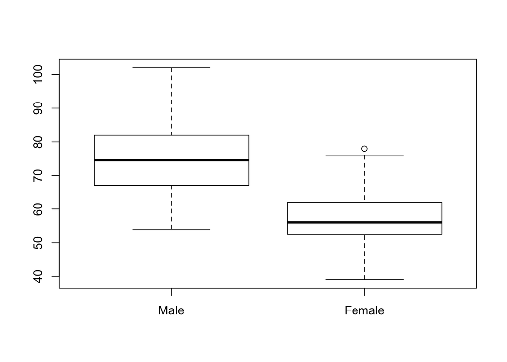

```r
# "No id variables; using all as measure variables" is a message that can be ignored
boxplot(data = meltdf, value ~ variable)
```

**Bonus: Now to make the above plot more informative and look “publication-ready”?**

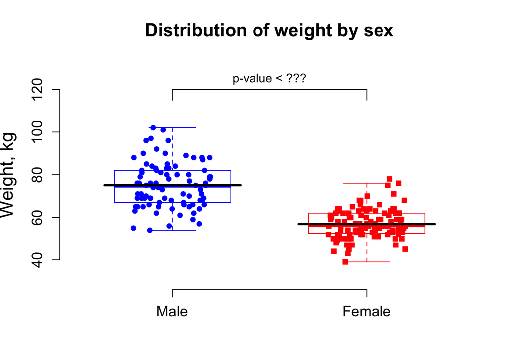

```r
# Define the plot parameters
y_limits <- c(30, 130)
colors <- c("blue", "red")
ylab <- "Weight, kg"
title <- "Distribution of weight by sex"

boxplot(data = meltdf, value ~ variable, outline = FALSE,
        #pars = list(boxwex = .4),
        ylab = ylab,
        cex.lab = 1.5, #to change (multiply) the font size of the axes legends
        cex.axis = 1.2, #to change (multiply) the font size of the axes
        ylim = y_limits,
        border = colors, #color the boxplot borders
        boxwex = 0.6,
        staplewex = 0.4,
        frame.plot = FALSE, #this removes upper and right borders on the plot area
        outwex = 0.5,
        cex.main = 1.5, #to change (multiply) the size of the title
        main = title # the title of the graph
        )

stripchart(data = meltdf, value ~ variable,
           col = colors,
           method = "jitter", jitter = .2,
           pch = c(16, 15), cex = c(1.0, 1.0), #different points and of different size can be used
           vertical = TRUE, add = TRUE)

# let's show the (yet unknown) significance level on the plot
text <- "p-value < ???"

y <- 120 # y position of the horizontal line
offset <- 5 # length of vertical segments
x <- 1

segments(x, y, x + 1, y)
segments(x, y - offset, x, y)
segments(x + 1, y - offset, x + 1, y)
text(x + 0.5, y + offset, paste(text), cex = 1) #cex defines the font size of the text

# you can also plot the means as sick (lwd = 3) horizontal black lines
y <- mean(Male, na.rm = T)
segments(x - 0.35, y, x + 0.35, y, lwd = 3)

y <- mean(Female, na.rm = T)
segments(x + 1 - 0.35, y, x + 1 + 0.35, y, lwd = 3)
```

#### Histogram

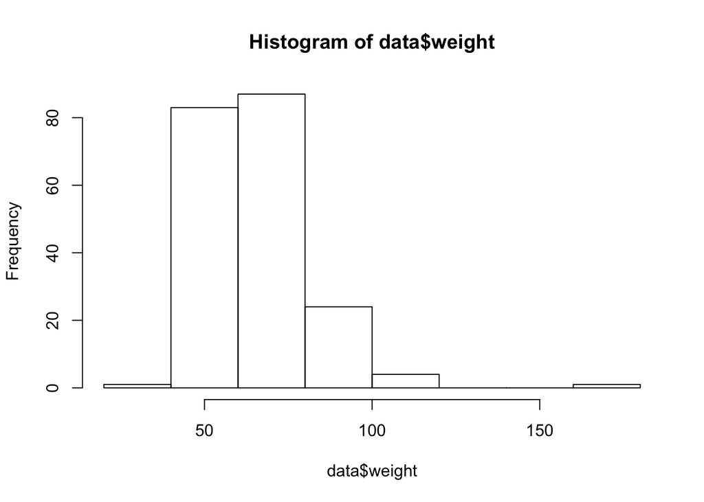

```r
hist(data$weight)
```

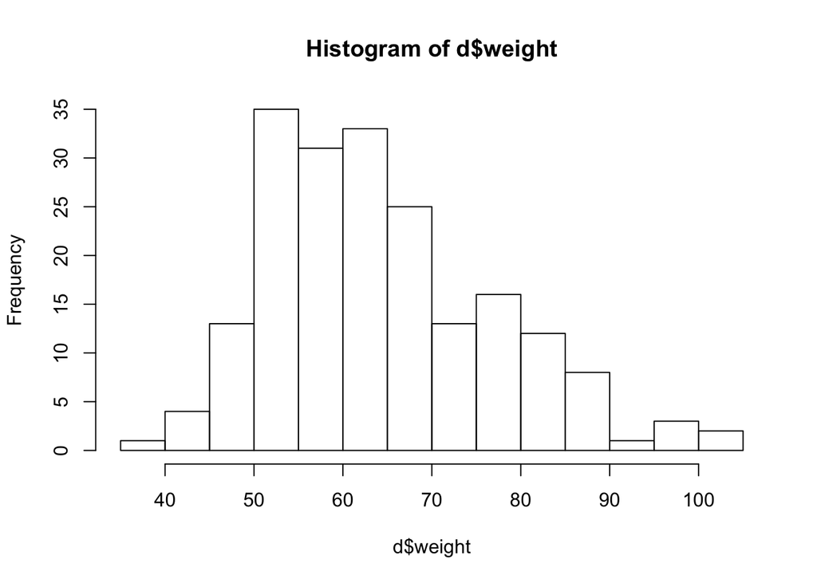

```r
hist(d$weight)
```

You can control for the size of bins!

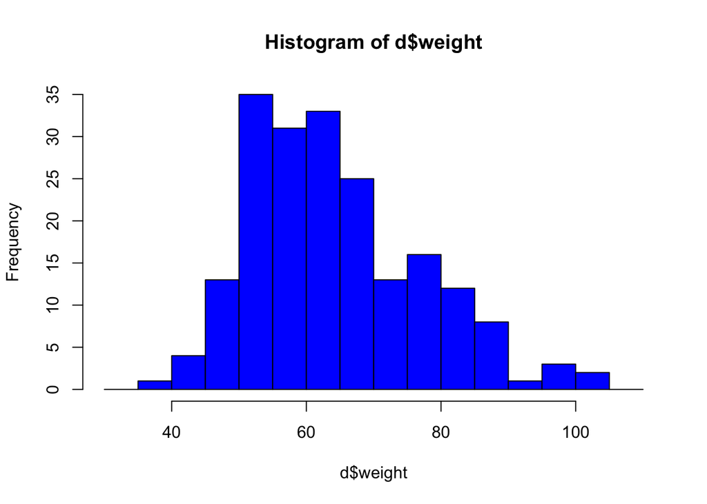

```r
bin_size <- 5
start <- 30
end <- 110
bins <- seq(start, end, by = bin_size)
hist(d$weight, breaks = bins, col = "blue")
```

**Bonus: Two overlaying histograms on one graph**

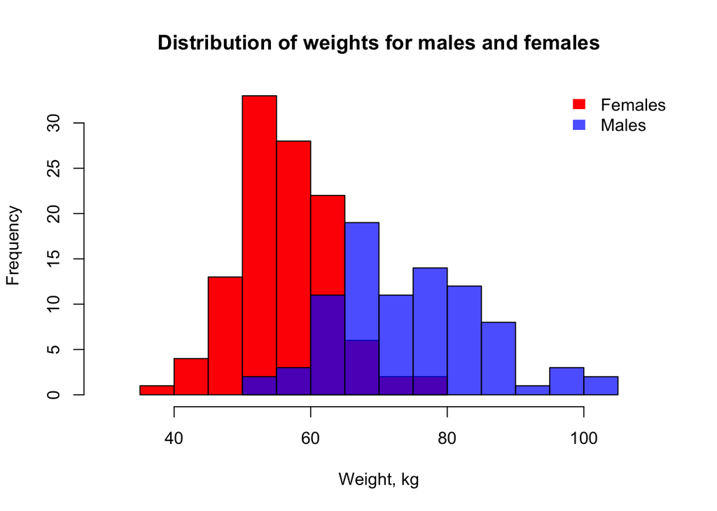

```r
xlim = c(start, end)
title <- "Distribution of weights for males and females"
colors <- c("red", rgb(0, 0, 1, 0.7)) # the last number in rgb() is for the transparency of the second color

hist(Female, col = colors[1], xlim = xlim, xlab = "Weight, kg", main = title)
hist(Male, add = TRUE, col = colors[2], xlim = xlim)
legend("topright", legend = c("Females", "Males"), fill = colors, bty = "n", border = NA)
```

#### Exercise with hist()

**Draw the same graph as above with bins of size 2 and using colors <- c(rgb(1, 0, 1, 0.7), rgb(0, 0, 1, 0.5))**

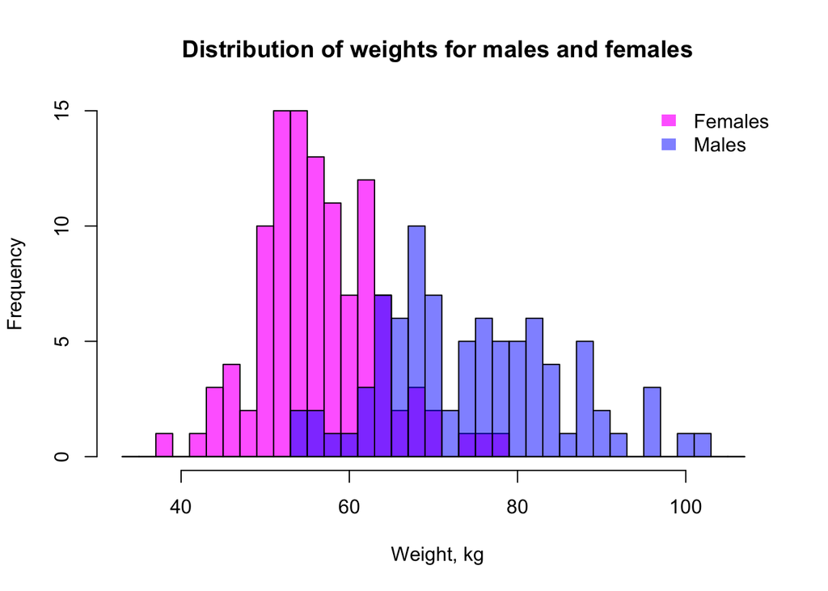

#### Scatterplot

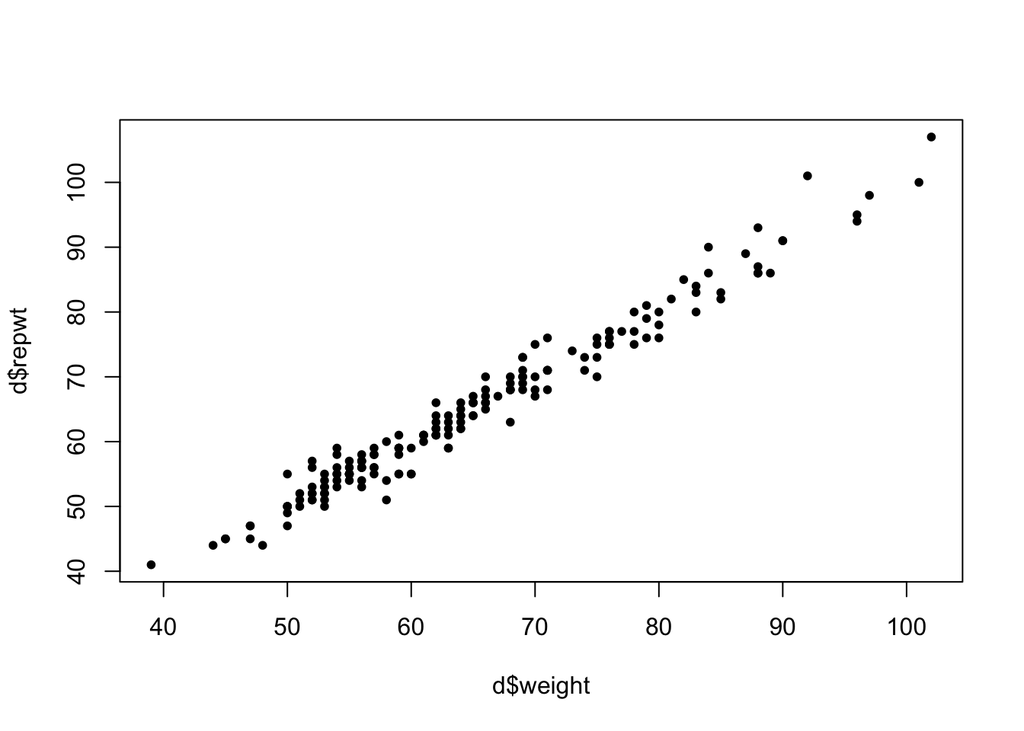

```r
plot(d$weight, d$repwt, pch = 20) # Just a simple plot of reported weights against measured weights
```

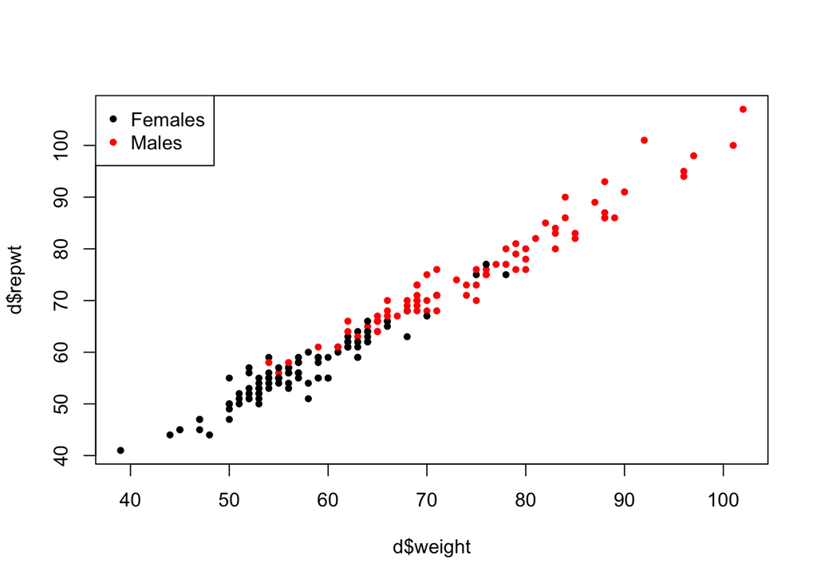

```r
plot(d$weight, d$repwt, pch = 20, col = d$sex) # it can be colored by sex, for example
legend("topleft",legend = c("Females", "Males"), col = 1:2, pch = 20)
```

Colors are taken in the order from the currently setup **palette()** .

```r
palette()
```

```
## [1] "black"   "red"     "green3"  "blue"    "cyan"    "magenta" "yellow"
## [8] "gray"
```

It can be changed to control for colors using palette() and then reset back to default, using palette(“default”).

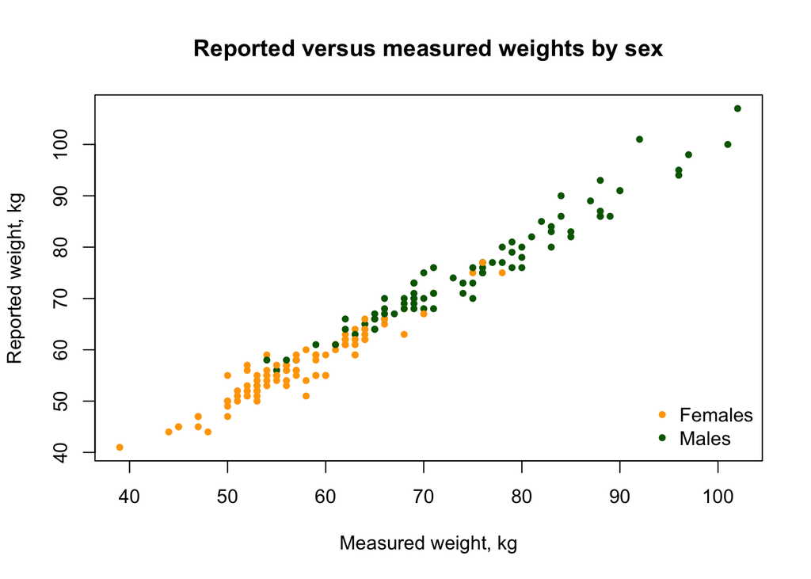

```r
palette(c("orange", "darkgreen")) # changing palette()
plot(d$weight, d$repwt, col = d$sex, pch = 20, xlab = "Measured weight, kg", ylab = "Reported weight, kg", main = "Reported versus measured weights by sex")
legend("bottomright",legend = c("Females", "Males"), col = 1:2, pch = 20, bty = "n")
```

```r
palette("default") # reset back to the default
```

#### Combining plots

Refer to http://www.statmethods.net/advgraphs/layout.html for using layout() function.

#### Empirical cumulative distribution functions (eCDFs)

**eCDF(x) = the proportion of observations which values are <= x**

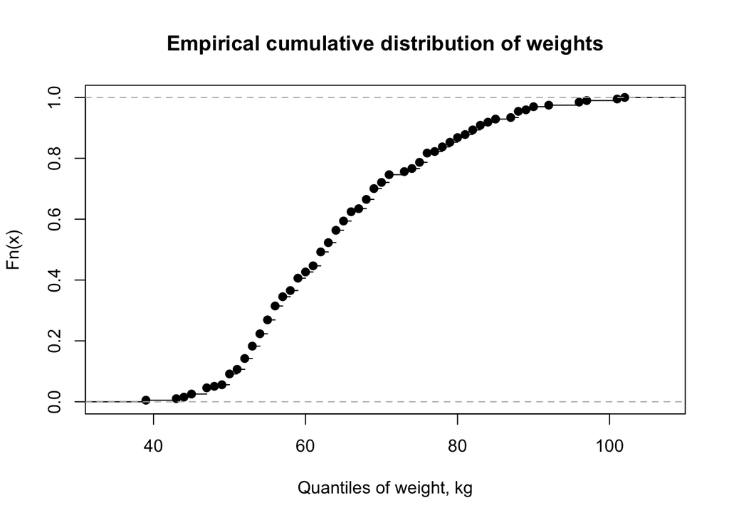

```r
weight.ecdf = ecdf(d$weight) # obtain empirical CDF values
plot(weight.ecdf, xlab = "Quantiles of weight, kg", main = "Empirical cumulative distribution of weights")
```

```r
plot(weight.ecdf, xlab = "Quantiles of weight, kg", main = "Empirical cumulative distribution of weights")
summary(d$weight)
```

```
##    Min. 1st Qu.  Median    Mean 3rd Qu.    Max.
##   39.00   55.00   63.00   64.83   73.00  102.00
```

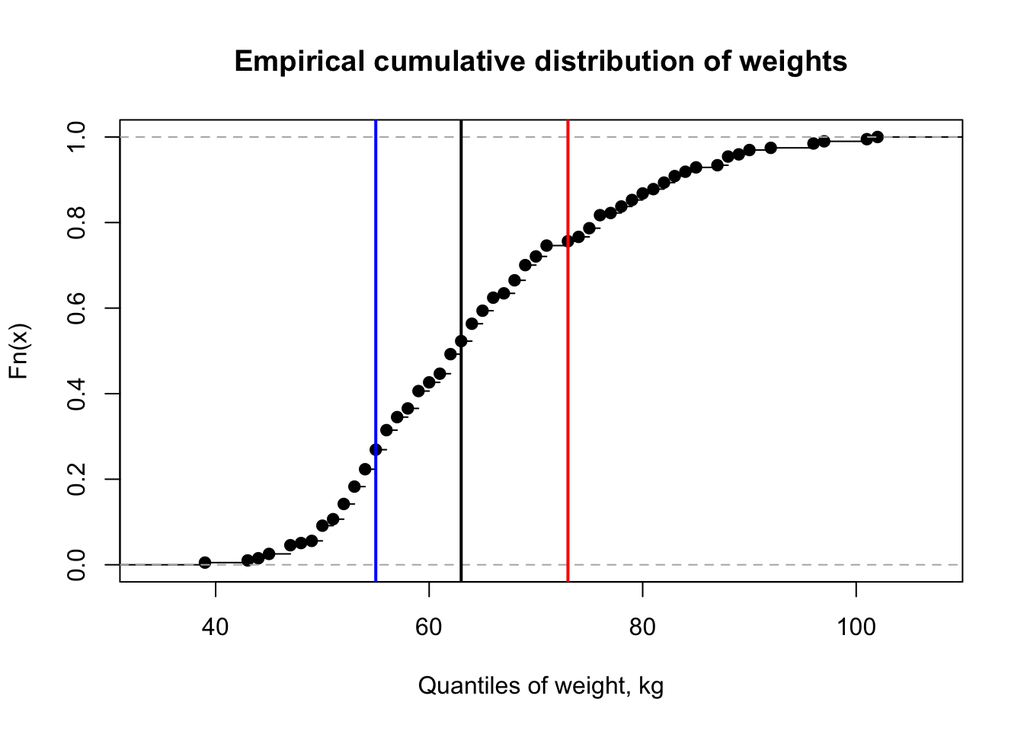

```r
x <- unname(summary(d$weight)) # a vector of 6 elements {min, Q1, median, mean, Q3, max}

abline(v = median(d$weight), lwd = 2) # vertical line for median
abline(v = x[2], col = "blue", lwd = 2) # vertical line for Q1
abline(v = x[5], col = "red", lwd = 2) # vertical line for Q3
```

Let’s draw horizontal lines for quantiles 0.5, 0.25, 0.75, using abline(h = …).

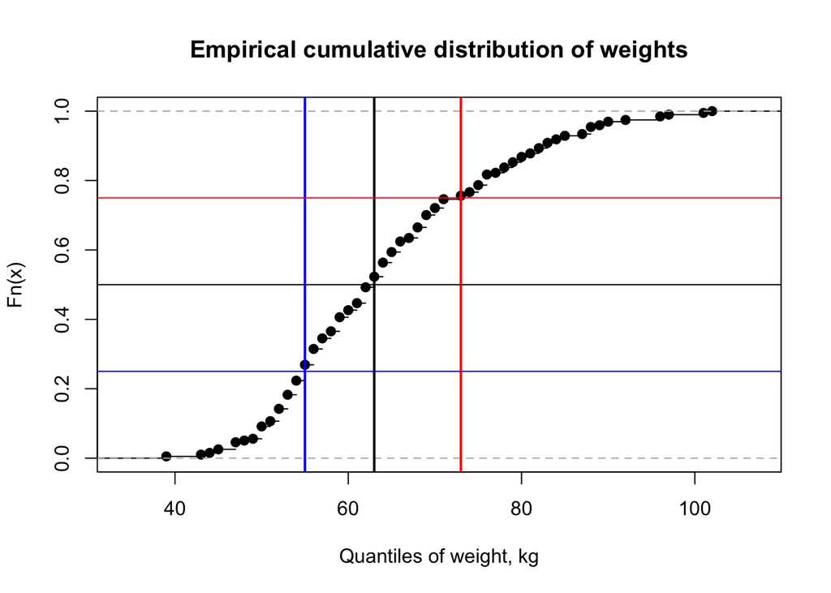

```r
plot(weight.ecdf, xlab = "Quantiles of weight, kg", main = "Empirical cumulative distribution of weights")
x <- unname(summary(d$weight)) # a vector of 6 elements {min, Q1, median, mean, Q3, max}
abline(v = median(d$weight), lwd = 2) # vertical line for median
abline(v = x[2], col = "blue", lwd = 2) # vertical line for Q1
abline(v = x[5], col = "red", lwd = 2) # vertical line for Q3

abline(h = 0.5) # median
abline(h = 0.25, col = "blue")
abline(h = 0.75, col = "red")
```

It can be seen that the CDF graph allows to identify the weight in kg for any quantile. For example, the lowest 10% of observations (CDF < 0.1) have weight below ~50 kg. Likewise, the top 10% of heavest people (CDF > 0.9) have weight above ~82 kg.

#### Exercise with eCDF

**Plot eCDFs for male and female weights in different colors on the same graph**

## 2. Distributions

### Normal distribution

**We will learn four important functions dnorm(), rnorm(), pnorm(), and qnorm().** See in addition https://www.r-bloggers.com/normal-distribution-functions/

#### Probability Density function (PDF)

We will use the following function:  
**dnorm() - Probability Density Function (PDF)**

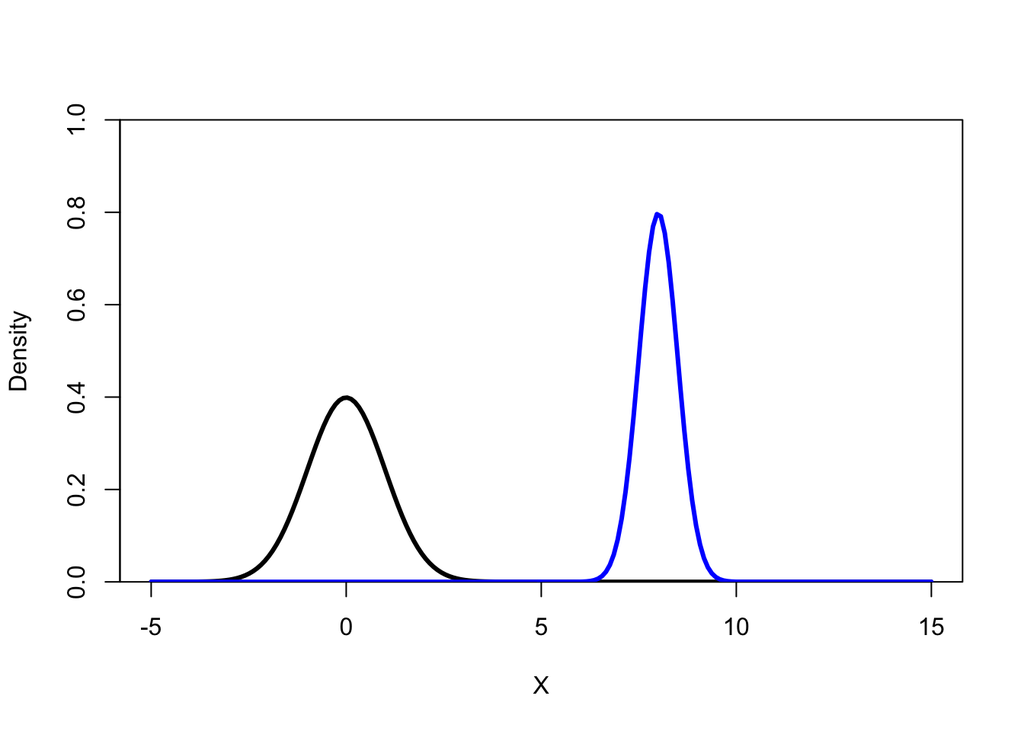

```r
x <- seq(-5, 15, length.out = 200)
y1 <- dnorm(x, mean = 0, sd = 1) # dnorm() !!!
y2 <- dnorm(x, mean = 8, sd = 0.5)

plot(x = x, y = y1, type = "l", lwd = 3, col = "black", ylim = c(0, 1), xlab = "X", ylab = "Density", yaxs = "i") # the last parameter forces the x-axes to meet the y-axes at 0
lines(x = x, y = y2, lwd = 3, col = "blue")
```

#### Z-transformation of a random sample from a normal distribution

We will use the following function:  
**rnorm() - generates random sample from a normal distribution**

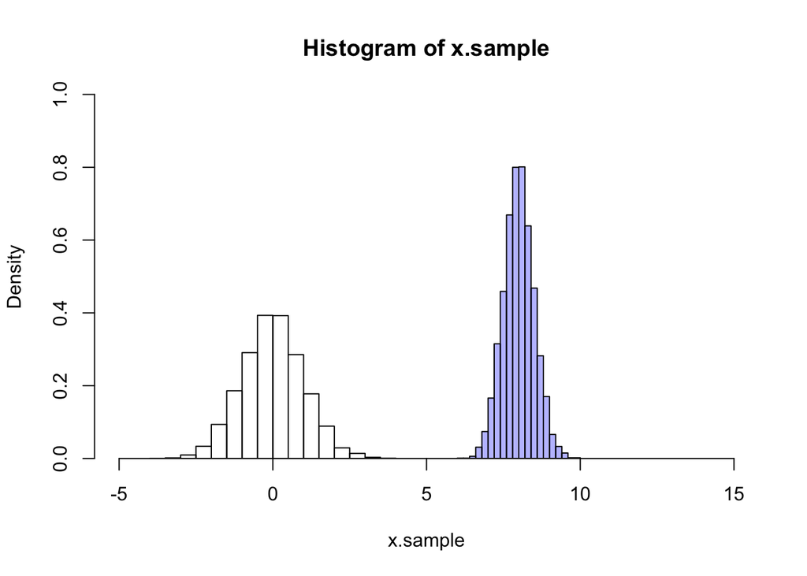

```r
mean <- 8
sd <- 0.5

x.sample <- rnorm(n = 5000, mean = mean, sd = sd) # rnorm() generates a random sample of size 500 from a normal distribution N(mean,sd)
z.sample <- (x.sample - mean) / sd # Z-transformation of x.sample

hist(x.sample, freq = F, ylim = c(0, 1), xlim = c(-5, 15), col = rgb(0,0,1,0.3), yaxs = "i")
hist(z.sample, freq = F, add = T)
```

Now if we overlay these histograms with the density functions plotted for normal distributions obtained before, we will see that sample distributions can be modelled by normal distributions: N(mean=8, sd=0.5) for x.sample and N(mean=0, sd=1) for a transformed z.sample. The black distribution is for the **standard normal distribution**.

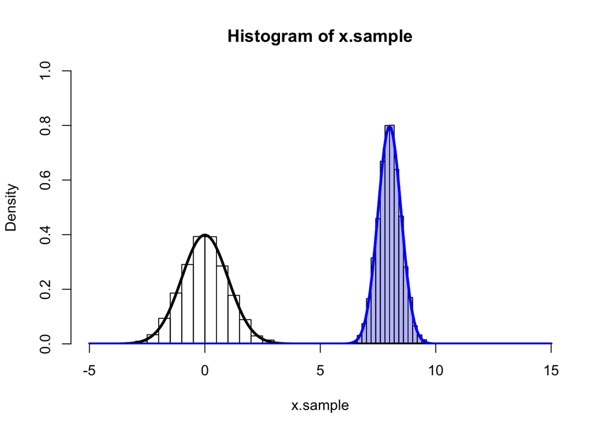

```r
hist(x.sample, freq = F, ylim = c(0, 1), xlim = c(-5, 15), col = rgb(0,0,1,0.3), yaxs = "i")
hist(z.sample, freq = F, add = T)

lines(x = x, y = y1, type = "l", lwd = 3)
lines(x = x, y = y2, lwd = 3, col = "blue")
```

#### Cumulative Distribution Function (CDF)

**pnorm(z, mu, sd) - gives an area under the standard normal curve to the left of z**

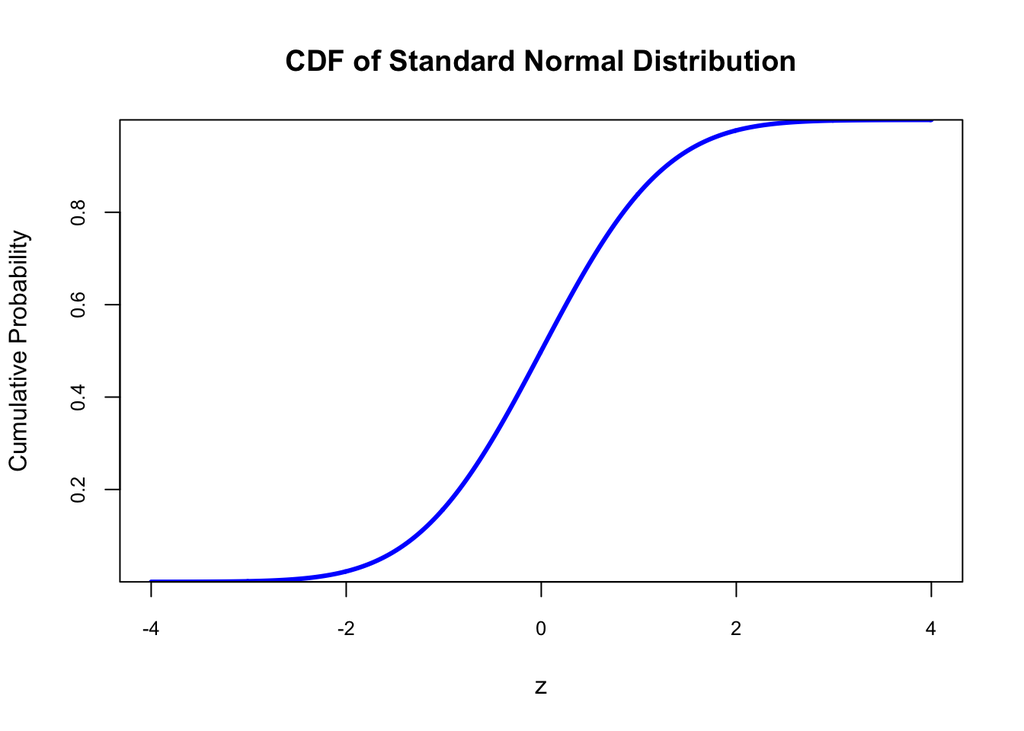

```r
z <- seq(-4, 4, 0.01)
cdf <- pnorm(z, 0, 1)

plot(z, cdf, col = "blue", xlab = "z", ylab = "Cumulative Probability", type = "l", lwd = 3, cex = 2, main = "CDF of Standard Normal Distribution", cex.axis = .8, yaxs = "i")
```

#### The 68-95-99.7 rule

For the Normal distribution with mean **mu** and standard deviation **sd**, **~68% of the observations fall within the range [mu - sd; mu + sd].**

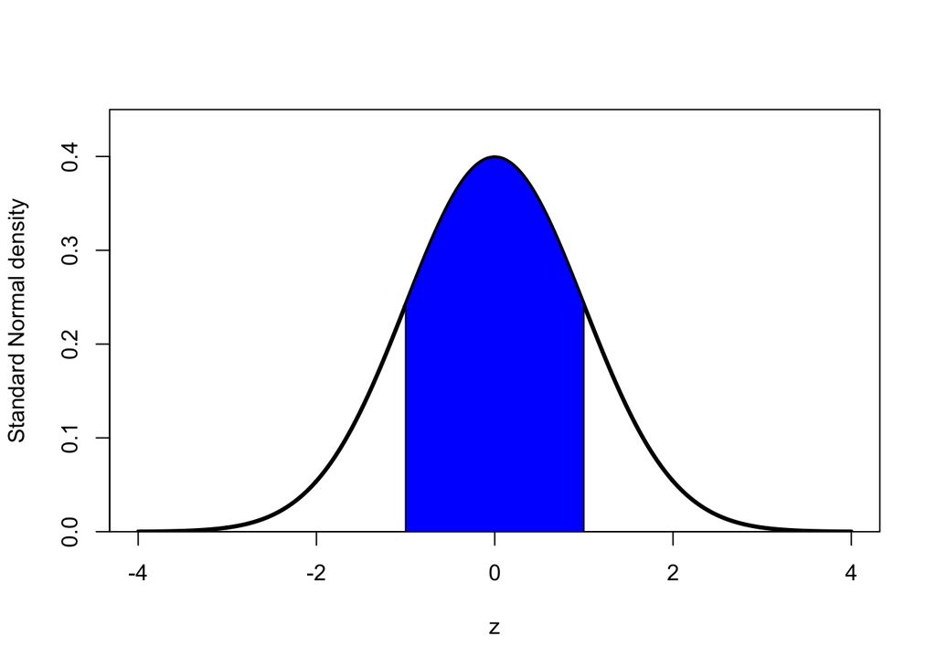

```r
z <- seq(-4, 4, 0.01)
dens <- dnorm(z)
plot(x = z, y = dens, type = "l", ylim = c(0,0.45), lwd = 3, xlab = "z", ylab = "Standard Normal density", yaxs = "i")

sd <- 1 # !!!!
xs <- c(seq(-sd, sd, length.out = 200))
ys <- dnorm(xs)
polygon(c(-sd, xs, sd), c(0, ys, 0), col = "blue")
```

```r
# What is the area of the blue area?
pnorm(sd) - pnorm(-sd)
```

```
## [1] 0.6826895
```

**~95.5% of the observations fall within the range [mu - 2sd; mu + 2sd].**

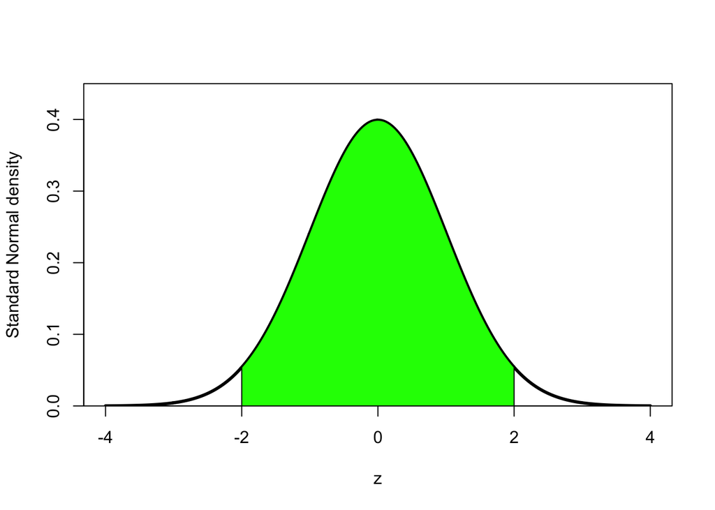

```r
plot(x = z, y = dens, type = "l", ylim = c(0,0.45), lwd = 3, xlab = "z", ylab = "Standard Normal density", yaxs = "i")

sd <- 2
xs <- c(seq(-sd, sd, length.out = 200))
ys <- dnorm(xs)
polygon(c(-sd, xs, sd), c(0, ys, 0), col = "green")
```

```r
# What is the area of the green area?
pnorm(sd) - pnorm(-sd)
```

```
## [1] 0.9544997
```

**~99.7% of the observations fall within the range [mu - 3sd; mu + 3sd].**

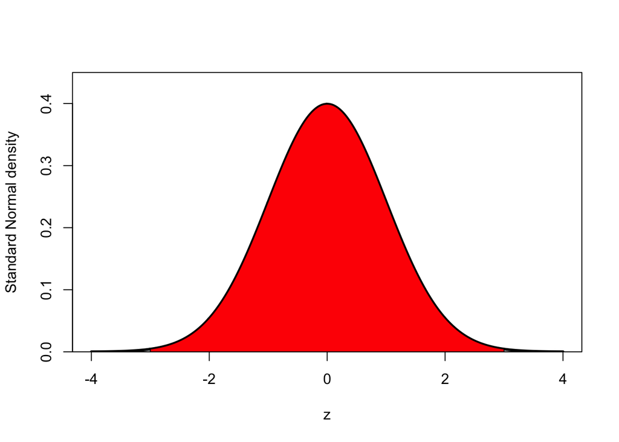

```r
plot(x = z, y = dens, type = "l", ylim = c(0,0.45), lwd = 3, xlab = "z", ylab = "Standard Normal density", yaxs = "i")

sd <- 3
xs <- c(seq(-sd, sd, length.out = 200))
ys <- dnorm(xs)
polygon(c(-sd, xs, sd), c(0, ys, 0), col = "red")
```

```r
# What is the area of the red area?
pnorm(sd) - pnorm(-sd)
```

```
## [1] 0.9973002
```

#### Quantile function, or How to obtain the critical values of -z and z for a specified area under the standard normal curve.

**qnorm(p, mu, sd) - gives the value of z at which CDF (area on the left of z) is equal p**

```r
#Find the critical values -z and z for the area under the standard normal curve of 95.5%
p <- 0.955
qnorm(p) #gives z such that P(X < z) = p
```

```
## [1] 1.695398
```

```r
qnorm(p + (1 - p) / 2) #gives a value of z such that P(-z < X < z) = p
```

```
## [1] 2.004654
```

It can be seen that this z = 2, or two standard deviations (sd = 1).